# Lab. 2 ARMA models

Análisis y Predicción de Series Temporales, 3º B IMAT

2024-09-013

# Lab. 2 ARMA models

# Preliminaries

## Load libraries

If you get an error go to the packages panel, click install and type the name of the library (you only need to do this once).

```r
library(fpp2)
library(tidyverse)
library(readxl)
library(lmtest) #contains coeftest function
```

To install the next one you need to:

- Download the file `MLTools_0.0.31.tar.gz` from Moodle ([R libraries section](https://sifo.comillas.edu/course/view.php?id=46499#section-9&module-3149241)).
- Go to the packages panel,
- Click *Install*
- Under *Install from* select *Package Archive File*
- Navigate to the folder where you downloaded the package and select it.
- Click install and wait for the setup to finish.

```r
library(MLTools)
```

## Set the working directory

```r
setwd(dirname(rstudioapi::getActiveDocumentContext()$path))
```

# Generating a time series using the ARMA process

Recall the equation of the ARMA(p, q) process:

$$(1 - \phi_1 B - \phi_2 B^2)y_t = (1 -
\theta_1 B - \theta_2 B^2)\epsilon_t$$
We use two vectors of coefficients for the AR and MA parts (with $p\leq 2, q\leq 2$). See the code lines below and make sure you choose the signs correctly.

```r
ar_cff <- c(0, 0)
ma_cff <- c(1/3, 0)
```

We will create a gaussian white noise time series. In order to do that we get a sample of $n$ random values from a standard normal $Z \sim N(0, 1)$.

```r
set.seed(2024)

n <- 800

w <- ts(rnorm(n, mean = 0, sd = 1) )
```

Now we generate a time series $y_t$ using the ARMA(p, q) process. In order to start the process we assume that the values of $y_t, w_t$ for $t < 1$ are 0.

```r
y <- numeric(n)

y[1] <- w[1]
y[2] <- w[2] + ar_cff[1] * y[1] - ma_cff[1] * w[1]

for(i in 3:n){
  y[i] <- ar_cff[1] * y[i - 1] + ar_cff[2] * y[i - 2] +
    w[i] - ma_cff[1] * w[i - 1] - ma_cff[2] * w[i - 2]
}

y <- ts(y)
```

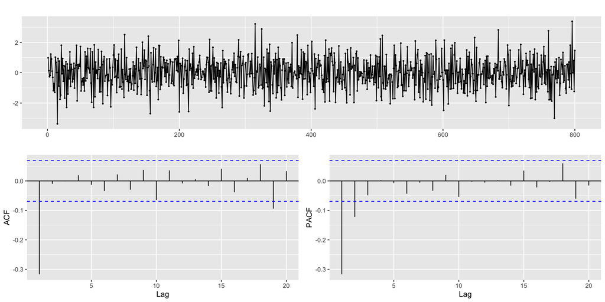

```r
ggtsdisplay(y, lag.max = 20)
```

## ARMA model selection and fit

Now we propose a structure of the model by selecting the values of p and q

```r
p <- 0
q <- 1

# We fit the model with estimated order

arima.fit <- Arima(y, order=c(p, 0, q), include.mean = FALSE)

# And we use `summary` to display the training errors and estimated coefficients.

summary(arima.fit)
```

```
## Series: y
## ARIMA(0,0,1) with zero mean
##
## Coefficients:
##           ma1
##       -0.3662
## s.e.   0.0333
##
## sigma^2 = 0.9582:  log likelihood = -1117.66
## AIC=2239.31   AICc=2239.33   BIC=2248.68
##
## Training set error measures:
##                      ME      RMSE      MAE      MPE     MAPE      MASE
## Training set 0.01173296 0.9782817 0.780829 669.0747 747.5282 0.5736278
##                     ACF1
## Training set 0.003191893
```

# Model diagnosis

The next function explores the statistical significance of the estimated coefficients

```r
coeftest(arima.fit)
```

```
##
## z test of coefficients:
##
##      Estimate Std. Error z value  Pr(>|z|)
## ma1 -0.366227   0.033329 -10.988 < 2.2e-16 ***
## ---
## Signif. codes:  0 '***' 0.001 '**' 0.01 '*' 0.05 '.' 0.1 ' ' 1
```

We use the information to update the ARMA structure if needed. Using autoplot with the fitted model results in a *root plot* to check stationarity and invertibility

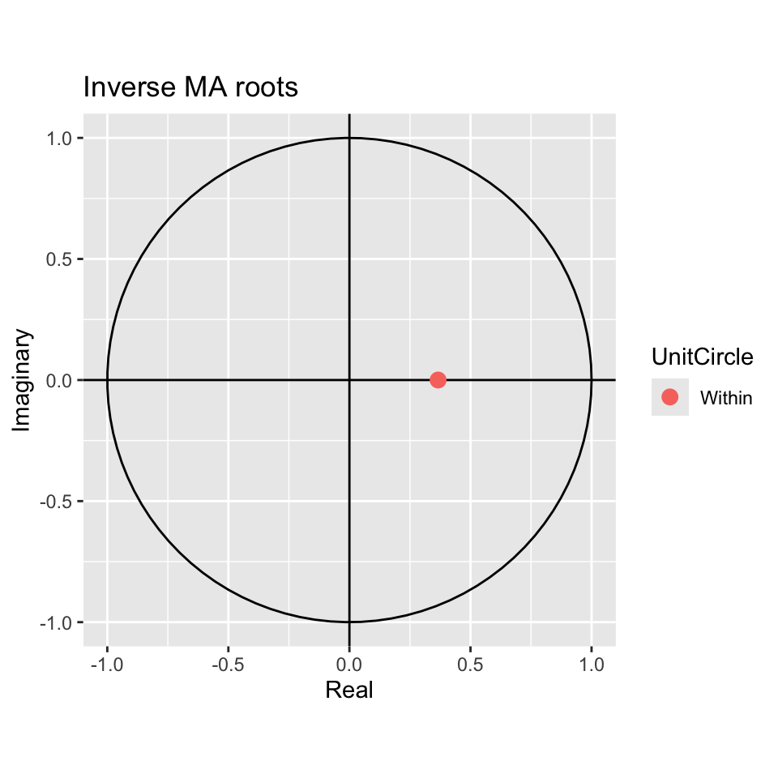

```r
autoplot(arima.fit)
```

## Checking the residuals

The residual plots can be used to check the hypothesis of the ARMA model:

- The time plot of the residuals should look like white noise (no patterns)
- The histogram and density curve help assess the normality.
- The ACF and PACF should show no significant values (up to 5%), in particular in the first lags.

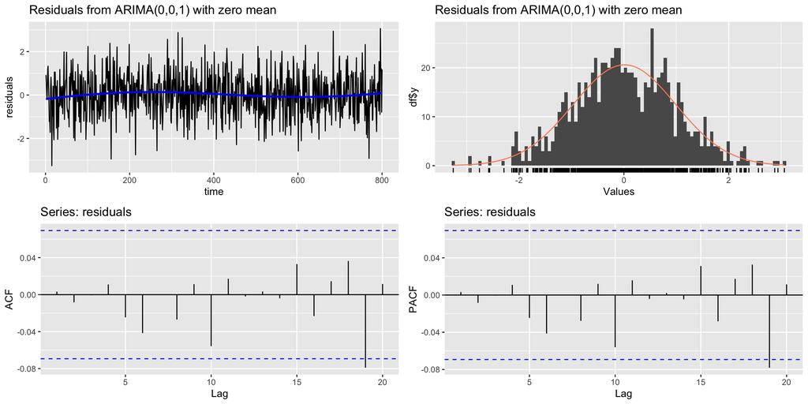

```
##
##  Ljung-Box test
##
## data:  Residuals from ARIMA(0,0,1) with zero mean
## Q* = 13.344, df = 19, p-value = 0.8205
##
## Model df: 1.   Total lags used: 20
```

```r
CheckResiduals.ICAI(arima.fit, bins = 100, lag=20)
```

Remember: you should also check the p-value of the Ljung-Box test in the output of `CheckResiduals`.

An alternative residual plot is obtained with

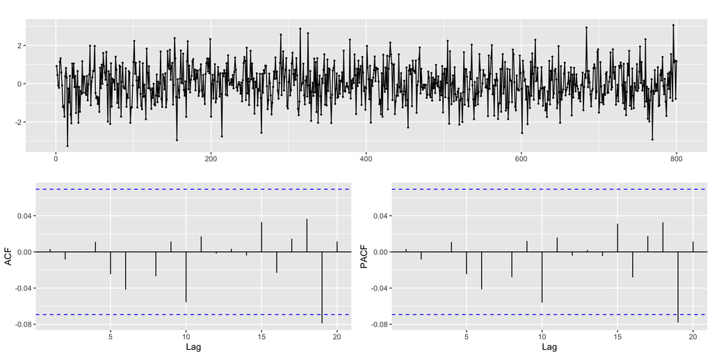

```r
ggtsdisplay(residuals(arima.fit), lag.max = 20)
```

Keep in mind that if the residuals are not white noise, you should change the order of the ARMA model.

# Fitted time series and forecasting with the fitted model

We begin by reconstructing the series with the model. That is, we obtain the fitted value at $t$
$$\hat{y}_{t|t-1}$$
for all $t$ in the training data.

The following plot compares the original time series with the reconstructed (fitted) values:

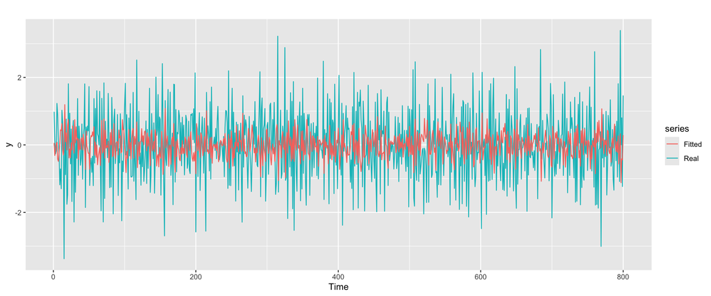

```r
autoplot(y, series = "Real") +
  forecast::autolayer(arima.fit$fitted, series = "Fitted")
```

Now, for a **true forecast of future values** we use the `horizon` parameter `h`:

```r
y_est <- forecast::forecast(arima.fit, h=5)
```

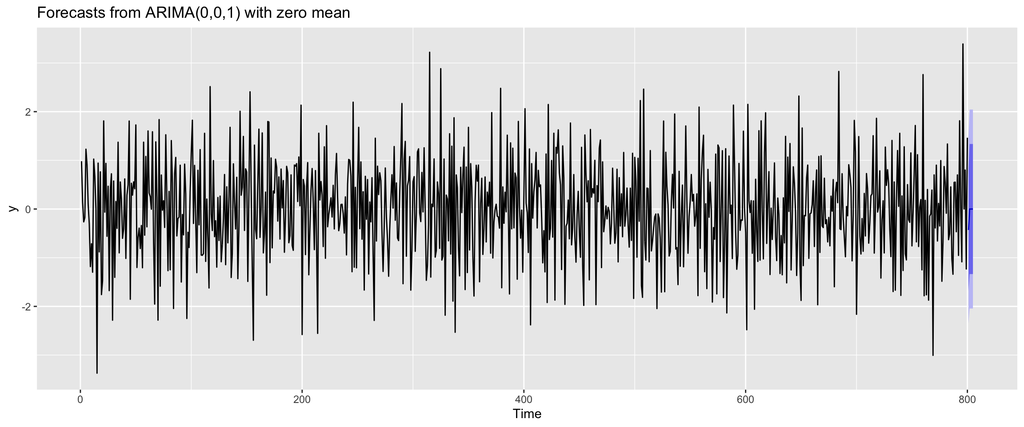

```r
autoplot(y_est)
```